# The Structure of Ill-Posed Inverse Problems in Experimental Particle Physics

## Introduction

## Clearing things up…

What is an inverse problem?

Where do they come from?

What makes them hard?

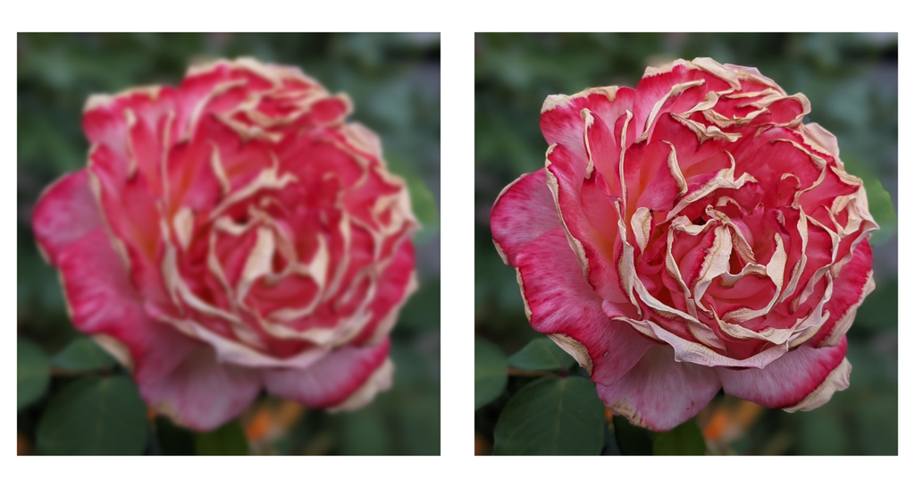

A rose in the Sunnyside neighborhood of Portland, OR. Original picture taken on 7/03/2021, a few days after the 2021 heat dome, during which the max temperatures at the Portland International Airport for 6/26-6/28 were respectively 108℉, 112℉, and 116℉ (source: https://projects.oregonlive.com/weather/temps/).

## On 1 Dimensional Data

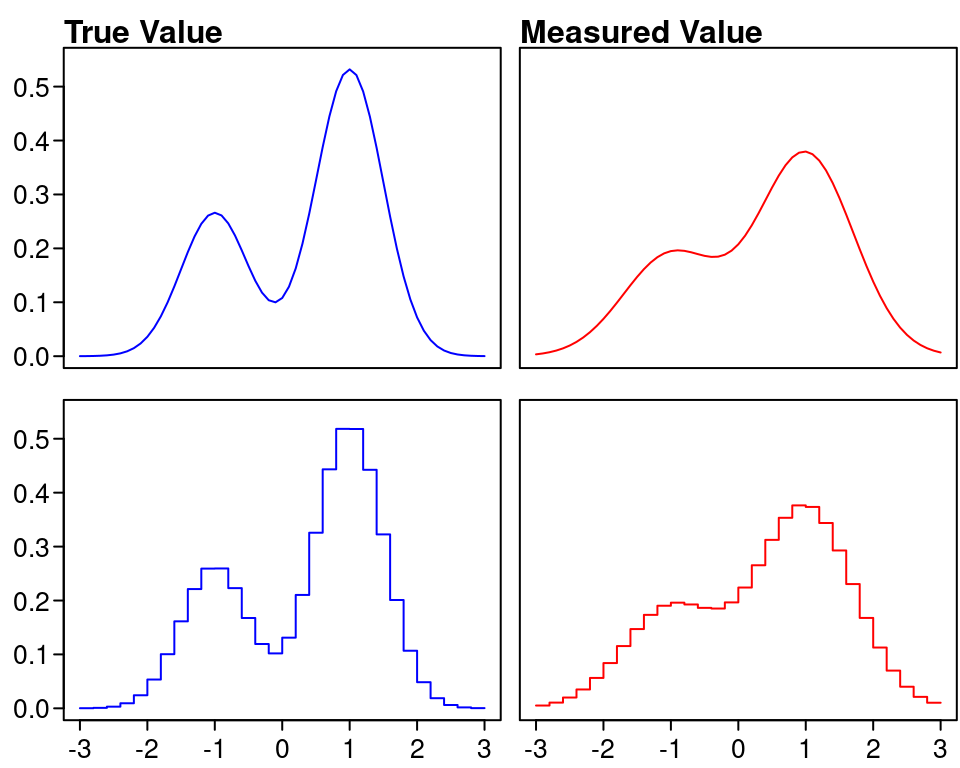

## Deconvolution

Simple model

Math

## Generalizing the Deconvolution

It’s unfolding now

Use a kernel

## Discrete Discretions

A new equation to solve

The response matrix

Efficiency

Poisson processes

Estimates

Unbiased Estimator

## Some Simulated Toy Models

The processes

The models and their distributions

Migration

## Unfolding

## Resources in particle physics

ROOT and RooUnfold

## Response Matrix Inversion

Basic premise

Weighted least squares solution

The pseudoinverse

An unbiased estimator

Ugly results

Why?

## Regularization

Tikhonov regularization and ridge regression

SVD

Data and notation transformations

SVD to distribute weights

Regularizing terms

Damped least squares

SVD to diagonalize response matrix and normalize response

Solution

Selecting tau one way

The purpose of unfolding

Selecting another way

Results and discussion

## Conclusion

Some other methods

## Acknowledgements

James, Heidi, NSF, committee, linear algebra, Soviet era physicists and mathematicians